# Assignment 3

John Drew

4/27/2021

## Introduction

In this assignment, I explored the relationships between variables in the college_recent_grads dataset from fivethirtyeight.com. The dataset contains 173 observations and 21 variables including major, rank based on median earnings, the total number of people that graduated with that major and more. While most the variables are numeric, Major and Major Category are both categorical variables. However, I will be focusing on the Major category and College Jobs variables. The table below provides a preview of the College Recent Grads dataset including all variables and they’re types.

```
## tibble [173 x 21] (S3: tbl_df/tbl/data.frame)
##  $ rank                       : int [1:173] 1 2 3 4 5 6 7 8 9 10 ...
##  $ major_code                 : int [1:173] 2419 2416 2415 2417 2405 2418 6202 5001 2414 2408 ...
##  $ major                      : chr [1:173] "Petroleum Engineering" "Mining And Mineral Engineering" "Metallurgical Engineering" "Naval Architecture And Marine Engineering" ...
##  $ major_category             : chr [1:173] "Engineering" "Engineering" "Engineering" "Engineering" ...
##  $ total                      : int [1:173] 2339 756 856 1258 32260 2573 3777 1792 91227 81527 ...
##  $ sample_size                : int [1:173] 36 7 3 16 289 17 51 10 1029 631 ...
##  $ men                        : int [1:173] 2057 679 725 1123 21239 2200 2110 832 80320 65511 ...
##  $ women                      : int [1:173] 282 77 131 135 11021 373 1667 960 10907 16016 ...
##  $ sharewomen                 : num [1:173] 0.121 0.102 0.153 0.107 0.342 ...
##  $ employed                   : int [1:173] 1976 640 648 758 25694 1857 2912 1526 76442 61928 ...
##  $ employed_fulltime          : int [1:173] 1849 556 558 1069 23170 2038 2924 1085 71298 55450 ...
##  $ employed_parttime          : int [1:173] 270 170 133 150 5180 264 296 553 13101 12695 ...
##  $ employed_fulltime_yearround: int [1:173] 1207 388 340 692 16697 1449 2482 827 54639 41413 ...
##  $ unemployed                 : int [1:173] 37 85 16 40 1672 400 308 33 4650 3895 ...
##  $ unemployment_rate          : num [1:173] 0.0184 0.1172 0.0241 0.0501 0.0611 ...
##  $ p25th                      : num [1:173] 95000 55000 50000 43000 50000 50000 53000 31500 48000 45000 ...
##  $ median                     : num [1:173] 110000 75000 73000 70000 65000 65000 62000 62000 60000 60000 ...
##  $ p75th                      : num [1:173] 125000 90000 105000 80000 75000 102000 72000 109000 70000 72000 ...
##  $ college_jobs               : int [1:173] 1534 350 456 529 18314 1142 1768 972 52844 45829 ...
##  $ non_college_jobs           : int [1:173] 364 257 176 102 4440 657 314 500 16384 10874 ...
##  $ low_wage_jobs              : int [1:173] 193 50 0 0 972 244 259 220 3253 3170 ...
```

## Methods and Results

```
## # A tibble: 1 x 2
##   avg_college_jobs percent_college
##              <dbl>           <dbl>
## 1           12323.           0.481
```

```
##
##     Agriculture & Natural Resources                                Arts
##                                  10                                   8
##              Biology & Life Science                            Business
##                                  14                                  13
##         Communications & Journalism             Computers & Mathematics
##                                   4                                  11
##                           Education                         Engineering
##                                  16                                  29
##                              Health           Humanities & Liberal Arts
##                                  12                                  15
## Industrial Arts & Consumer Services                   Interdisciplinary
##                                   7                                   1
##                 Law & Public Policy                   Physical Sciences
##                                   5                                  10
##            Psychology & Social Work                      Social Science
##                                   9                                   9
```

This can be more easily observed in the ‘Number of Majors per Category’ graph where the Engineering bar is noticeably larger than all the rest. However when looking at the ‘Avg. # of College Jobs by Category’ graph it is apparent that although Engineering has the largest variety of majors, as a category is does not even rank in the top 5 of majors leading in jobs that require college degrees.

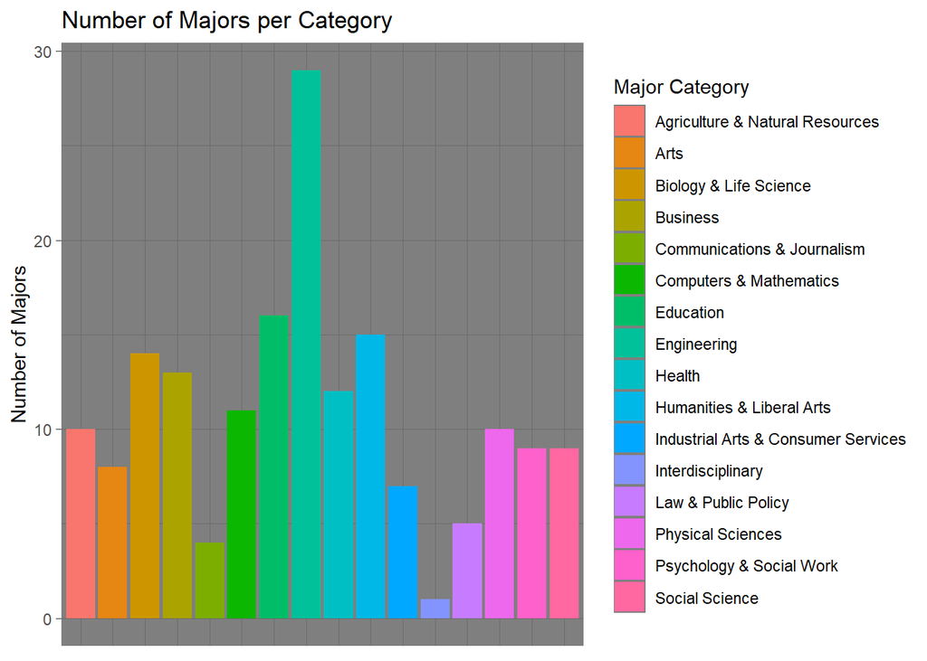

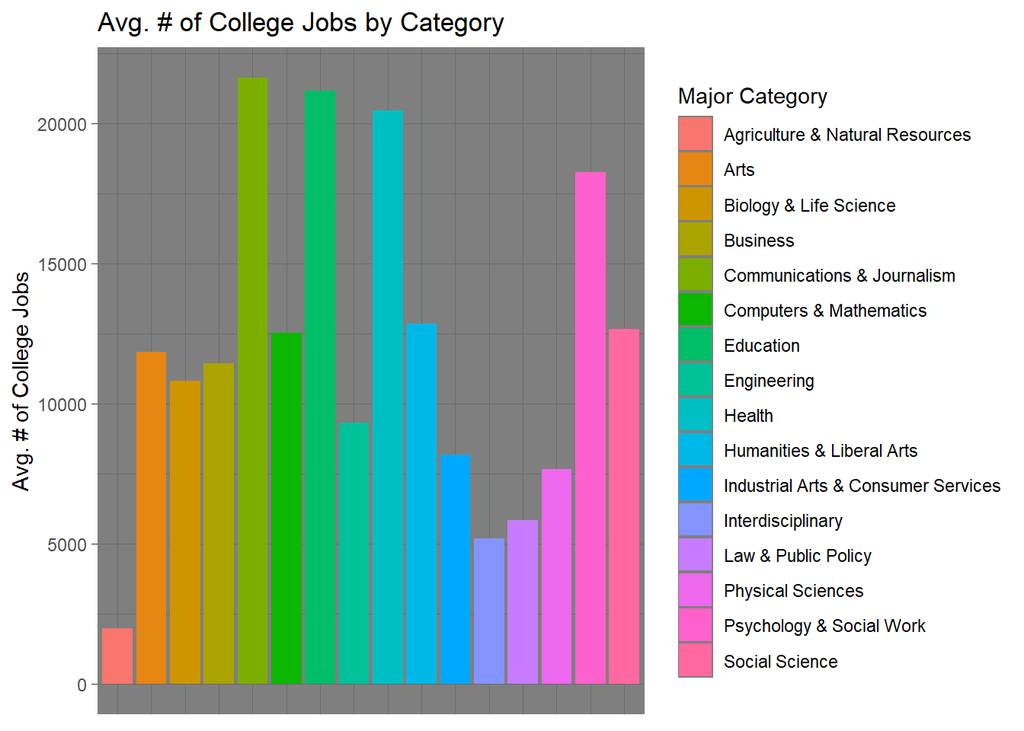

While exploring each of the variables, I came across a relationship between Major, total number of people in a major and the number of jobs that require a college degree. The graph below begins to illustrate this. When looking at the graph it is important to recognize how each variable is being represented. Each point represents a major and as before, the x-axis represents each major category which is then represented by the respective colors in the legend, and the y-axis represents the total number of jobs that require a degree for each Major. The third variable, total number of people in a major, is introduced and represented by the size of the point. Now that we understand how to interpret the visualizaton, we can begin to understand the implications.

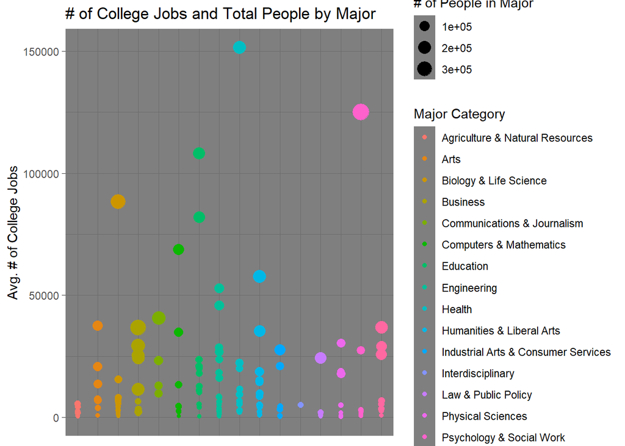

## Conclusion

The first thing that becomes noticeable is that generally, the dots get larger as the number of college jobs increases meaning that there is a larger number of people with that major. Knowing this, we can start to reach the conclusion that regardless of what specific major is in question, students tend to enroll in majors with a higher number of jobs that require college degrees. This means that a large amount of students either conciously or unknowingly gravitate to job paths that actually require college degrees.